# Process data for meta analyses of the IRAP’s reliability

Using stricter performance exclusion criteria

Ian Hussey

28 March 2023

```r
# set seed for computational reproducibility
set.seed(42)

# dependencies
library(tidyverse)
library(metafor)
library(knitr)
library(kableExtra)
library(psych)
library(readxl)
library(janitor)

# n iterations in permutation resampling procedures
n_iterations <- 1000

# function to round all numeric vars in a data frame
round_df <- function(df, n_digits = 3) {
  df %>% mutate_if(is.numeric, round, digits = n_digits)
}

spearman_brown_correction <- function(r_pearson) {
  inversion <- ifelse(r_pearson < 0, -1, 1)
  val <- 2*abs(r_pearson)/(1 + abs(r_pearson))
  return(val*inversion)
}

apa_p_value <- function(p){
  p_formatted <- ifelse(p >= 0.001, paste("=", janitor::round_half_up(p, 3)),
                        ifelse(p < 0.001, "< .001", NA))
  p_formatted <- gsub(pattern = "0.", replacement = ".", x = p_formatted, fixed = TRUE)
  p_formatted
}

add_heterogeneity_metrics_to_forest <- function(fit) {
  bquote(paste("RE Model (", tau^2, " = ", .(formatC(janitor::round_half_up(fit$tau2, 1))),
               ", ", I^2, " = ", .(formatC(janitor::round_half_up(fit$I2, 1))),
               "%, ", H^2," = ", .(formatC(janitor::round_half_up(fit$H2, 1))), ")"))
}

# using Ruscio's own code
ruscios_A_function <- function(x, y) {
  nx <- length(x)
  ny <- length(y)
  rx <- sum(rank(c(x, y))[1:nx])
  A = (rx / nx - (nx + 1) / 2) / ny
  return(A)
}

ruscios_A <- function(data, variable = "rt", group = "block_type", value1 = "inconsistent", value2 = "consistent") {
  # Ensure data is a data frame (e.g., not a tbl_data)
  data <- as.data.frame(data)
  # Select the observations for group 1
  x <- data[data[[group]] == value1, variable]
  # Select the observations for group 2
  y <- data[data[[group]] == value2, variable]
  A.obs <- ruscios_A_function(x, y)
  return(as.numeric(A.obs))
}

# test retest icc
calculate_icc <- function(data) {
  require(psych)

  fit <- data %>%
    select(baseline, followup) %>%
    ICC(lmer = FALSE)

  results <- fit$results %>%
    filter(type == "ICC2") %>%
    select(type, ICC, ICC_ci_lower = "lower bound", ICC_ci_upper = "upper bound") %>%
    mutate(se = (ICC_ci_upper - ICC_ci_lower)/(1.96*2))

  return(results)
}

# table format in output
options(knitr.table.format = "html")

# create directory needed to save output
dir.create("permutations")
```

# Get data and exclude outliers

Exclude outliers on the basis of median mean_rt < 2000 and accuracy >=80% on every block pair.

```r
# all
data_outliers <- read_csv("../trial level/data_trial_level.csv") |>
  mutate(timepoint = dplyr::recode(timepoint,
                                   "1" = "baseline",
                                   "2" = "followup"))

data_outliers_removed <- data_outliers |>
  filter(met_performance_criteria_stricter == TRUE)

# subset ic
data_ic <- data_outliers_removed %>%
  filter(timepoint == "baseline")

# subset trt
data_unique_ids_two_timepoints <- data_outliers_removed %>%
  filter(timepoint %in% c("baseline", "followup")) %>%
  distinct(unique_id, timepoint, .keep_all = TRUE) %>%
  select(unique_id, timepoint, domain) %>%
  mutate(present = TRUE) %>%
  spread(timepoint, present) %>%
  filter(baseline == TRUE & followup == TRUE) %>%
  select(unique_id)

data_trt <- data_unique_ids_two_timepoints %>%
  left_join(data_outliers_removed, by = "unique_id")
```

# Demographics & sample sizes

Save demographics data to disk

```r
# write demographics to disk
data_demographics <- data_outliers_removed %>%
  distinct(unique_id, .keep_all = TRUE) %>%
  select(unique_id, domain, age, gender, met_performance_criteria_stricter) %>%
  filter(!domain %in% c("Clinton-Trump",
                        "Disgust (1)",
                        "Disgust (2)",
                        "Countries (1)",
                        "Countries (2)",
                        "Countries (3)",
                        "Countries (4)",
                        "Race (2)",
                        "Valenced words",
                        "Rich-Poor",
                        "Sexuality (1)",
                        "Sexuality (2)",
                        "Shapes & colors (5)",
                        "Shapes & colors (6)",
                        "Shapes & colors (7)",
                        "Gender (1)",
                        "Gender (2)") &
           !str_detect(domain, "Personality") &
           !str_detect(domain, "Stigma"))

data_additional_demographics <- read_csv("../trial level/additional_demographics_data.csv") %>%
  rename(gender = sex)

data_demographics_combined <-
  bind_rows(data_demographics,
            data_additional_demographics) %>%
  select(-unique_id, -participant, -met_performance_criteria_stricter) %>%
  filter(!is.na(age) | !is.na(gender))

#write_csv(data_demographics_combined, "data_demographics.csv")
```

Sample sizes

```r
# print sample sizes
data_outliers_removed %>%
  distinct(unique_id, .keep_all = TRUE) %>%
  count(met_performance_criteria_stricter) %>%
  rename(n_outlier_exclusions = n) %>%
  kable() %>%
  kable_classic(full_width = FALSE)
```

| met_performance_criteria_stricter | n_outlier_exclusions |
| --- | --- |
| TRUE | 1336 |

```r
data_ic %>%
  distinct(unique_id, .keep_all = TRUE) %>%
  count(domain) %>%
  rename(n_ic_after_exlucions = n) %>%
  kable() %>%
  kable_classic(full_width = FALSE)
```

| domain | n_ic_after_exlucions |
| --- | --- |
| Body image | 16 |
| Clinton-Trump | 74 |
| Countries (3) | 29 |
| Countries (4) | 16 |
| Death (1) | 9 |
| Death (2) | 14 |
| Death (3) | 23 |
| Death (4) | 28 |
| Disgust (1) | 31 |
| Friend-Enemy | 65 |
| Gender stereotypes (1) | 36 |
| Gender stereotypes (2) | 76 |
| Gender stereotypes (3) | 172 |
| Gender stereotypes (4) | 39 |
| Lincoln-Hitler | 75 |
| Non-words | 21 |
| Personality - Agreeableness | 28 |
| Personality - Conscientiousness | 27 |
| Personality - Extraversion | 22 |
| Personality - Neuroticism | 18 |
| Personality - Openness | 6 |
| Professor competence | 18 |
| Race (1) | 29 |
| Race (2) | 12 |
| Religion | 20 |
| Rich-Poor | 52 |
| Self-competence (am) | 50 |
| Self-competence (want to be) | 49 |
| Sexuality (1) | 24 |
| Shapes & colors (1) | 6 |
| Shapes & colors (2) | 11 |
| Shapes & colors (3) | 4 |
| Shapes & colors (4) | 6 |
| Stigma - ADHD | 52 |
| Stigma - PTSD | 45 |
| Stigma - Schizophrenia | 44 |

```r
data_ic %>%
  distinct(unique_id, .keep_all = TRUE) %>%
  count() %>%
  rename(n_ic_after_exlucions = n) %>%
  kable() %>%
  kable_classic(full_width = FALSE)
```

| n_ic_after_exlucions |
| --- |
| 1247 |

```r
data_trt %>%
  distinct(unique_id, .keep_all = TRUE) %>%
  count(domain) %>%
  rename(n_trt_after_exlucions = n) %>%
  kable() %>%
  kable_classic(full_width = FALSE)
```

| domain | n_trt_after_exlucions |
| --- | --- |
| Body image | 12 |
| Friend-Enemy | 32 |
| Gender stereotypes (1) | 34 |
| Lincoln-Hitler | 43 |
| Race (1) | 23 |
| Religion | 18 |
| Sexuality (1) | 24 |

```r
data_trt %>%
  distinct(unique_id, .keep_all = TRUE) %>%
  count() %>%
  rename(n_trt_after_exlucions = n) %>%
  kable() %>%
  kable_classic(full_width = FALSE)
```

| n_trt_after_exlucions |
| --- |
| 186 |

# Internal consistency

Three methods of calculating internal consistency for the Implicit Relational Assessment Procedure (IRAP): - Odd vs even trials (mostly commonly reported in literature) - First vs second half of task (more common for the most popular implicit measure, the IAT; would allow a like-for-like comparison) - Cronbach’s alpha via permutation (most robust)

## Permutation-based split half correlations

ie an estimate of alpha through large number number of random half splits (see Parsons, Kruijt, & Fox. 2019).

Because of the large number of D/A scores that are calculated (i.e., 2 per participant * N participants * N permutations = several million scores) this section can take a several minutes to run. I’ve already done some timing optimization to speed up this process by a factor of 5, but perhaps more is possible.

### Score

```r
# slow runtime - circa 10 minutes, so check if there's saved results already first
if (file.exists("permutations/data_D_scores_internal_consistency_permutations_stricter.RData")) {

  load("permutations/data_D_scores_internal_consistency_permutations_stricter.RData")

} else {

  # find domain for each id - to be joined into df further below
  data_domain_for_each_id <- data_ic %>%
    distinct(unique_id, .keep_all = TRUE) %>%
    select(unique_id, domain)

  # create a temp list
  data_internal_consistency_list = list()

  # define progress bar
  step_i <- 0
  pb = txtProgressBar(min = 0, max = n_iterations, initial = 0)

  # assign row ids
  data_ic_rownumbers <- data_ic %>%
    arrange(unique_id, block_type) %>%
    mutate(row_id = row_number()) %>%
    group_by(unique_id, block_type) %>%
    mutate(trial_number = row_number()) %>%
    ungroup()

  # apply workflow and append results to list
  for(i in 1:n_iterations){

    # sample exactly half of the data and label as subset 'a' vs 'b'
    max_trials_per_block <- data_ic_rownumbers |>
      summarize(max_trials_per_block = max(trial_number)) |>
      pull(max_trials_per_block)

    trial_subset_a <- data.frame(trial_number = seq(from = 1, to = max_trials_per_block, by = 1)) |>
      sample_frac(size = 0.5) |>
      arrange(trial_number) |>
      pull(trial_number)

    data_ic_rownumbers_with_subsets <- data_ic_rownumbers |>
      mutate(subset = ifelse(trial_number %in% trial_subset_a, "a", "b")) |>
      arrange(unique_id, block_type, trial_number)

    # # calculate a metric of how ordered this randomized subset of the trials are
    # ## start by creating the 'b' vector
    # temp <- seq(from = 1, to = max_trials_per_block, by = 1)
    # trial_subset_b <- temp[!temp %in% trial_subset_a]
    #
    # ## probability that b > a
    # probability_of_superiority <- ruscios_A_function(trial_subset_b, trial_subset_a)
    #
    # subset_orderedness <- abs(probability_of_superiority - 0.50) + 0.5

    # then calculate D1 scores (Greenwald, Banaji & Nosek, 2003)
    # these involve: 1) trimming RTs > 10000 ms, 2) finding a mean rt for each block type, 3) findings an sd for all the pooled RTs across blocks, 4) D = (mean_incon - mean_con)/sd
    data_temp_1 <- data_ic_rownumbers_with_subsets |>
      filter(rt <= 10000)

    data_temp_2 <- data_temp_1 |>
      group_by(unique_id, subset, block_type) |>
      summarize(mean = mean(rt, na.rm = TRUE), .groups = "keep") |>
      ungroup() |>
      spread(block_type, mean) |>
      rename(mean_con = consistent,
             mean_incon = inconsistent)

    data_temp_3 <- data_temp_1 |>
      group_by(unique_id, subset) |>
      summarize(sd = sd(rt, na.rm = TRUE), .groups = "keep") |>
      ungroup()

    data_internal_consistency <- left_join(data_temp_2, data_temp_3, by = c("unique_id", "subset")) |>
      # finish calculating D scores for each participant and subset
      mutate(D = (mean_incon - mean_con)/sd) |>
      select(unique_id, D, subset) |>
      spread(subset, D) |>
      rename(D_a = a,
             D_b = b) |>
      # re add the study domain
      left_join(data_domain_for_each_id, by = "unique_id") |>
      # calculate correlations between subsets
      na.omit() |>
      group_by(domain) |>
      summarize(r_pearson = cor(D_a, D_b), .groups = "keep") |>
      ungroup() |>
      # apply spearman brown correction
      mutate(r_sb = spearman_brown_correction(r_pearson)) |>
      # add iteration
      mutate(iteration = i)
    #orderedness = subset_orderedness)

    data_internal_consistency_list[[i]] <- data_internal_consistency

    # update progress bar
    step_i = step_i + 1
    setTxtProgressBar(pb, step_i)

  }

  # flatten list and parse results
  data_D_scores_internal_consistency_permutations <- dplyr::bind_rows(data_internal_consistency_list)

  # save
  save(data_D_scores_internal_consistency_permutations,
       file = "permutations/data_D_scores_internal_consistency_permutations_stricter.RData")

}
```

### Calculate effect sizes

Bonett transformations

Also includes response option location for later moderator meta analysis

```r
data_n_per_domain <- data_ic %>%
  distinct(unique_id, .keep_all = TRUE) %>%
  count(domain) %>%
  select(domain, n)

data_response_option_locations <- data_ic %>%
  distinct(domain,
           response_option_locations,
           trials_per_block,
           response_option_locations)

data_D_scores_internal_consistency_permuted_estimates <- data_D_scores_internal_consistency_permutations %>%
  group_by(domain) %>%
  dplyr::summarize(alpha = mean(r_sb, na.rm = TRUE),
                   alpha_ci_lower = quantile(r_sb, 0.025),
                   alpha_ci_upper = quantile(r_sb, 0.975)) %>%
  left_join(data_n_per_domain, by = "domain") %>%
  left_join(data_response_option_locations, by = "domain") %>%
  mutate(parts = 2) %>%
  escalc(measure = "ABT",
         ai = alpha,
         mi = parts,
         ni = n,
         data = .)

write_csv(data_D_scores_internal_consistency_permuted_estimates,
          "data_D_scores_internal_consistency_permuted_estimates_stricter.csv")
```

# Test-retest reliability

## Score

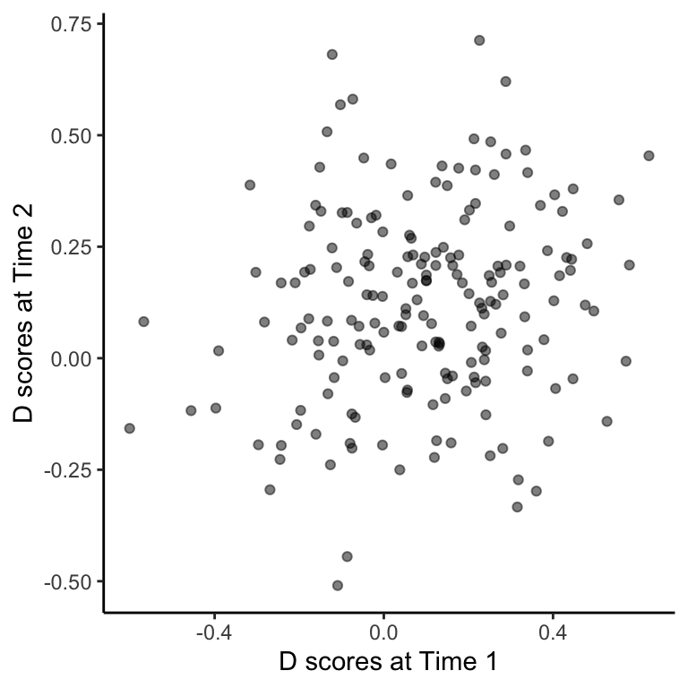

```r
data_D_scores_trt <- data_trt %>%
  filter(rt <= 10000) %>%
  group_by(unique_id, timepoint) %>%
  summarize(mean_con = mean(rt[block_type == "consistent"], na.rm = TRUE),
            mean_incon = mean(rt[block_type == "inconsistent"], na.rm = TRUE),
            sd = sd(rt, na.rm = TRUE)) %>%
  ungroup() %>%
  mutate(D = (mean_incon - mean_con)/sd) %>%
  select(unique_id, D, timepoint) %>%
  spread(timepoint, D) %>%
  left_join(select(distinct(data_trt, unique_id, .keep_all = TRUE), unique_id, domain), by = "unique_id")

ggplot(data_D_scores_trt, aes(baseline, followup)) +
  geom_point(alpha = .5) +
  theme_classic() +
  #coord_cartesian(ylim = c(-.51, .51), xlim = c(-.51, .51)) +
  xlab("D scores at Time 1") +
  ylab("D scores at Time 2")
```

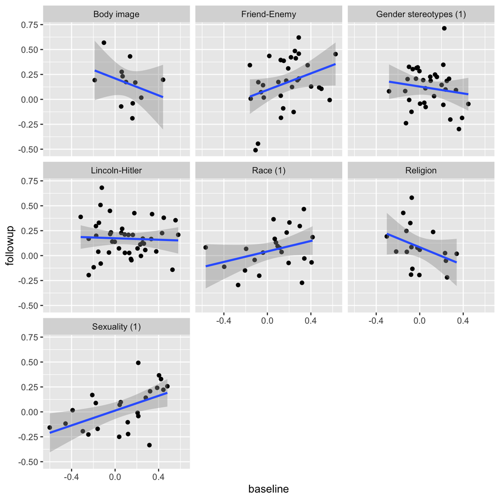

```r
ggplot(data_D_scores_trt, aes(baseline, followup)) +
  geom_point() +
  geom_smooth(method = "lm") +
  facet_wrap(~domain)
```

## Calculate effect sizes

### ICC

```r
data_D_scores_test_retest_icc <- data_D_scores_trt %>%
  group_by(domain) %>%
  do(calculate_icc(.)) %>%
  ungroup() %>%
  left_join(data_D_scores_trt %>%
              count(domain), by = "domain")

write_csv(data_D_scores_test_retest_icc, "data_D_scores_test_retest_icc_stricter.csv")
```

Variance associated with each effect size calculated mathematically using the effect size and sample size.